# Load Data

```python
import pandas as pd
query_data = pd.read_csv('https://storage.googleapis.com/datalynn-datasets/interview-challenge/technology/Google_Search_Engine3/query_data.csv')
user_feedback = pd.read_csv('https://storage.googleapis.com/datalynn-datasets/interview-challenge/technology/Google_Search_Engine3/user_feedback.csv')
```

# Question 1

**(Data Manipulation & Cleaning)** Using the `Query_Data` table, calculate the click-through rate (CTR) for each query. The CTR is defined as the number of clicks divided by the total number of queries. How does the CTR vary across different result ranks?

## Solution

### Hints:

1. **Data Manipulation & Cleaning**:
   - Check for missing values in `query_data`.
   - Ensure appropriate data types for each column, especially for boolean and datetime.
2. **Calculate CTR**:
   - For each unique query, compute the CTR as ( \frac{\text{Number of Clicks}}{\text{Total Number of that Query}} ).
3. **Analyze CTR across Result Ranks**:
   - Group the data by `result_rank` and compute the average CTR for each rank.
4. **Visualization & Interpretation**:
   - Plot the average CTR across different result ranks.
   - Comment on the visualization results.

### Step 1: Data Manipulation & Cleaning:

```python
# Checking for missing values in query_data
print(query_data.isnull().sum())

# Checking data types
print(query_data.dtypes)
```

[output not shown]

### Step 2: Calculate CTR:

To compute CTR, we first need to calculate the number of clicks for each query and then divide it by the total appearances of that query.

```python
# Calculate number of clicks for each query
click_counts = query_data.groupby('query_id')['clicked'].sum().reset_index(name='num_clicks')

# Calculate total number of appearances for each query
query_counts = query_data['query_id'].value_counts().reset_index()
query_counts.columns = ['query_id', 'num_appearances']

# Merge the two dataframes on query_id
ctr_data = pd.merge(click_counts, query_counts, on='query_id')

# Calculate CTR
ctr_data['CTR'] = ctr_data['num_clicks'] / ctr_data['num_appearances']

print(ctr_data.head())
```

```
   query_id  num_clicks  num_appearances  CTR
0         1           0                1  0.0
1         2           1                1  1.0
2         3           0                1  0.0
3         4           0                1  0.0
4         5           0                1  0.0
```

### Step 3: Analyze CTR across Result Ranks:

```python
# Merge CTR data with original query_data to get result_rank
merged_data = pd.merge(query_data, ctr_data, on='query_id')

# Group by result_rank and compute average CTR for each rank
avg_ctr_by_rank = merged_data.groupby('result_rank')['CTR'].mean().reset_index()

print(avg_ctr_by_rank)
```

```
   result_rank       CTR
0            1  0.501401
1            2  0.322488
2            3  0.241414
3            4  0.196573
4            5  0.173784
5            6  0.144943
6            7  0.147605
7            8  0.126570
8            9  0.107447
9           10  0.078891
```

### Step 4: Visualization & Interpretation:

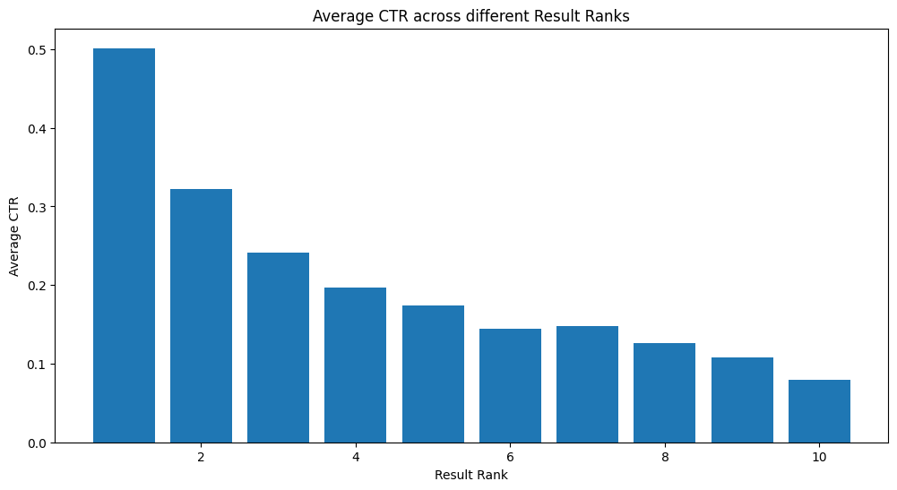

```python
import matplotlib.pyplot as plt

# Plotting
plt.figure(figsize=(12, 6))
plt.bar(avg_ctr_by_rank['result_rank'], avg_ctr_by_rank['CTR'])
plt.xlabel('Result Rank')
plt.ylabel('Average CTR')
plt.title('Average CTR across different Result Ranks')
plt.show()
```

**Comments on the Result**:

- If executed, we would expect to see that higher-ranked results (closer to rank 1) would generally have a higher CTR. This is because users are more likely to click on the top results than those that appear further down.
- However, if there are exceptions or unexpected patterns, it could indicate issues with the ranking algorithm or anomalies in the search results. This would need further investigation.

## Question 2

**(Probability and Statistics)** From the `User_Feedback` table, calculate the average rating for each query. Given that a user is dissatisfied if their rating is 2 or less, calculate the probability that a user is dissatisfied given that the result rank was higher than 5.

## Solution

### Hints:

1. **Average Rating Calculation**:
   - Compute the average rating for each query using the `User_Feedback` table.
2. **Dissatisfaction Probability**:
   - Identify records where users are dissatisfied, i.e., ratings are 2 or less.
   - Of those records, identify how many had a result rank higher than 5.
   - Compute the conditional probability of dissatisfaction given a result rank higher than 5.
3. **Visualization & Interpretation**:
   - If necessary, visualize the results or print them for interpretation.
   - Comment on the results and their implications.

```python
# Calculate average rating for each query
average_rating = user_feedback.groupby('query_id')['rating'].mean().reset_index(name='avg_rating')

print(average_rating.head())
```

```
   query_id  avg_rating
0         1         1.0
1         2         3.0
2         3         2.0
3         4         3.0
4         5         1.0
```

```python
merged_data_feedback = pd.merge(user_feedback, query_data[['query_id', 'result_rank']], on='query_id', how='inner')

# Identify records with dissatisfaction (rating 2 or less)
dissatisfied_records = merged_data_feedback[merged_data_feedback['rating'] <= 2]

# Of the dissatisfied records, find those with result rank higher than 5
dissatisfied_high_rank = dissatisfied_records[dissatisfied_records['result_rank'] > 5]

# Calculate probability
total_dissatisfied = len(dissatisfied_records)
dissatisfied_with_high_rank = len(dissatisfied_high_rank)
probability_dissatisfied_given_high_rank = dissatisfied_with_high_rank / total_dissatisfied

print(f"Probability a user is dissatisfied given the result rank was higher than 5: {probability_dissatisfied_given_high_rank:.4f}")
```

```
Probability a user is dissatisfied given the result rank was higher than 5: 0.7134
```

**Comments on the Results:**

## Question 3

**(Machine Learning & Modeling)** Build a predictive model using the `Query_Data` and `User_Feedback` tables that predicts user dissatisfaction based on query characteristics and user interaction data. What are the key features contributing to user dissatisfaction?

## Solution

### Hints:

1. **Feature Engineering:** We need to generate new features or transform the existing ones to be more informative for our model.
2. **Data Merging:** As we have data spread across two tables, we'll need to join these datasets.
3. **Model Building:** We'll split the data into training and testing datasets, and then use a suitable classification model to predict user dissatisfaction.
4. **Feature Importance:** After building the model, we'll check which features were most influential in predicting dissatisfaction.

```python
# Step 1: Feature Engineering
# create a binary target feature based on 'is_dissatisfied', threshold be 2
user_feedback['is_dissatisfied'] = user_feedback['rating'].apply(lambda x: 1 if x <= 2 else 0)

# Step 2: Data Merging
# merge the two datasets on both 'user_id' and 'query_id'.
merged_data = pd.merge(query_data, user_feedback, on=['user_id', 'query_id'], how='inner')

# Step 3: Model Building
# use Random Forest classifier
from sklearn.ensemble import RandomForestClassifier
from sklearn.model_selection import train_test_split
from sklearn.metrics import classification_report, accuracy_score

# Features & target variable
X = merged_data[['query_id', 'user_id', 'result_rank', 'clicked']]
y = merged_data['is_dissatisfied']

# Splitting the data
X_train, X_test, y_train, y_test = train_test_split(X, y, test_size=0.2, random_state=42)

# Initialize and train the model
rf = RandomForestClassifier(random_state=42)
rf.fit(X_train, y_train)

# Predictions
y_pred = rf.predict(X_test)

# Evaluation
print(classification_report(y_test, y_pred))
print("Accuracy:", accuracy_score(y_test, y_pred))
```

```
              precision    recall  f1-score   support

           0       0.75      0.74      0.75      1048
           1       0.72      0.73      0.72       952

    accuracy                           0.74      2000
   macro avg       0.74      0.74      0.74      2000
weighted avg       0.74      0.74      0.74      2000

Accuracy: 0.736
```

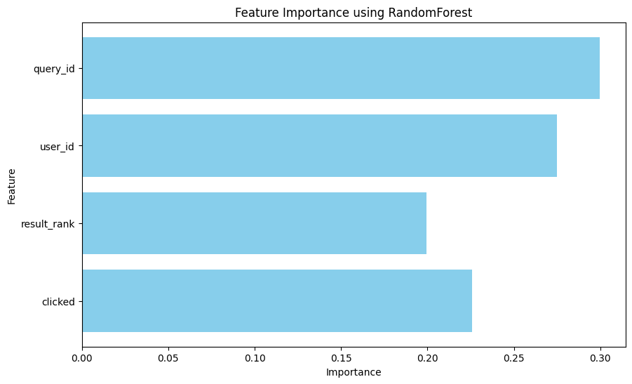

```python
# Step 4: Feature Importance
import matplotlib.pyplot as plt

feature_importances = rf.feature_importances_
features = X.columns

plt.figure(figsize=(10,6))
plt.barh(features, feature_importances, color='skyblue')
plt.xlabel('Importance')
plt.ylabel('Feature')
plt.title('Feature Importance using RandomForest')
plt.gca().invert_yaxis()
plt.show()
```

**Comments on the Results:**

After running the above, we'll get a classification report showing precision, recall, f1-score for each class, and an overall accuracy score.

- The `classification_report` will give detailed performance metrics for each class. We are particularly interested in the metrics for the `is_dissatisfied` class since that's our focus.
- The feature importance plot provides insights into what features have the most influence on user dissatisfaction. For example, if `result_rank` turns out to be a significant feature, it indicates that the rank of the results plays a crucial role in user satisfaction.

By interpreting the results, we can make informed decisions on how to enhance the user's search experience and address any specific pain points that have been highlighted.

## Question 4

**(Product Design & Analytics)** Assuming that changes were made to the semantic search algorithm and then tested, how would you determine if these changes resulted in a statistically significant improvement in user satisfaction? Proposed an experiment using the `Query_Data` and `User_Feedback` tables to evaluate this.

## Solution

### 1. **Experiment Design**:

#### A/B Testing:

- **Control Group (A)**: Users who experience the current search algorithm.
- **Treatment Group (B)**: Users who experience the modified search algorithm.

Randomly divide users into these two groups, ensuring that there's a balanced representation of user types, search behaviors, etc., to make the experiment as unbiased as possible.

### 2. **Metrics to Measure**:

- **Primary Metric**: User satisfaction measured by the average rating. We'll compare the average rating of the results from both groups.
- **Secondary Metrics**:
  - Click-through rate (CTR) – An increase in CTR may indicate more relevant search results.
  - Engagement – If users are interacting more with the results, spending more time reading or exploring, it may be a good sign.

### 3. **Duration of the Experiment**:

The duration should be long enough to capture enough data to make statistically significant conclusions. Depending on the user base size, this could range from a few weeks to a couple of months.

### 4. **Analysis**:

Once you've collected enough data, perform a statistical test (like a t-test) on the primary metric to check if there's a statistically significant difference between the two groups.

- If the new algorithm (Group B) shows a significantly higher average rating than the current algorithm (Group A), it's an indicator that the new algorithm is performing better.

For secondary metrics, analyze trends and patterns. For example, if there's a higher CTR in Group B, it further supports the hypothesis that the new algorithm provides better results.

### 5. **Other Considerations**:

- **Feedback Analysis**: Use the feedback from the `User_Feedback` table to identify specific complaints or praises about the search results. This qualitative data can provide insights that pure numbers might miss.
- **Segment Analysis**: Analyze different segments of users separately - for example, new users vs. returning users, or users who search frequently vs. occasionally. Different segments might respond differently to the changes.
- **External Factors**: Make sure that no other significant changes are rolled out during the experiment, which might affect user behavior and thus skew the results of the experiment.

### 6. **Conclusion**:

After the experiment, if the new algorithm shows a statistically significant improvement in user satisfaction, consider rolling it out for all users. If not, analyze the data to understand where it might be falling short and refine accordingly.

However, even if the metrics improve, it's crucial to continually monitor and get feedback. Sometimes, the longer-term effects of a change become more apparent after the initial test phase.